# Lab 08 - Text Mining

```r
knitr::opts_chunk$set(eval = TRUE, include  = T)
```

# Learning goals

- Use `unnest_tokens()` and `unnest_ngrams()` to extract tokens and ngrams from text.
- Use dplyr and ggplot2 to analyze text data

# Lab description

For this lab we will be working with the medical record transcriptions from https://www.mtsamples.com/. And is loaded and “fairly” cleaned at https://github.com/JSC370/jsc370-2023/blob/main/data/medical_transcriptions/.

### Setup packages

You should load in `dplyr`, (or `data.table` if you want to work that way), `ggplot2` and `tidytext`. If you don’t already have `tidytext` then you can install with

```r
# install.packages("tidytext")
```

### read in Medical Transcriptions

Loading in reference transcription samples from https://www.mtsamples.com/

```r
library(tidytext)
library(readr)
library(dplyr)
library(tidyr)
library(forcats)

library(ggplot2)
data_url <- paste0(
  "https://raw.githubusercontent.com/JSC370/",
  "jsc370-2023/main/data/medical_transcriptions/mtsamples.csv"
  )
mt_samples <- read_csv(data_url)
mt_samples <- mt_samples |>
  select(description, medical_specialty, transcription)
head(mt_samples)
```

```
## # A tibble: 6 × 3
##   description                                                    medic…¹ trans…²
##   <chr>                                                          <chr>   <chr>
## 1 A 23-year-old white female presents with complaint of allergi… Allerg… "SUBJE…
## 2 Consult for laparoscopic gastric bypass.                       Bariat… "PAST …
## 3 Consult for laparoscopic gastric bypass.                       Bariat… "HISTO…
## 4 2-D M-Mode. Doppler.                                           Cardio… "2-D M…
## 5 2-D Echocardiogram                                             Cardio… "1.  T…
## 6 Morbid obesity.  Laparoscopic antecolic antegastric Roux-en-Y… Bariat… "PREOP…
## # … with abbreviated variable names ¹medical_specialty, ²transcription
```

## Question 1: What specialties do we have?

We can use `count()` from `dplyr` to figure out how many different categories we have. Are these categories related? overlapping? evenly distributed?

```r
mt_samples |> count(medical_specialty, sort = TRUE)
```

```
## # A tibble: 30 × 2
##    medical_specialty                 n
##    <chr>                         <int>
##  1 Surgery                        1103
##  2 Orthopedic                      355
##  3 Radiology                       273
##  4 General Medicine                259
##  5 Gastroenterology                223
##  6 Neurology                       223
##  7 SOAP / Chart / Progress Notes   166
##  8 Obstetrics / Gynecology         160
##  9 Urology                         158
## 10 Neurosurgery                     94
## # … with 20 more rows
```

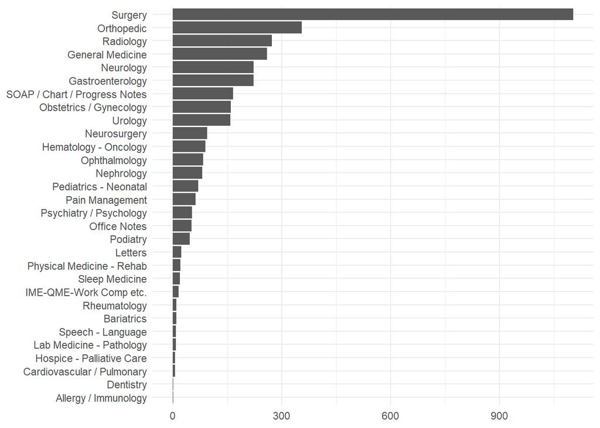

```r
mt_samples |> count(medical_specialty, sort = TRUE) |>
  mutate(medical_specialty = fct_reorder(medical_specialty, n))|>
  ggplot(aes(medical_specialty, n)) +
  theme_minimal() +
  geom_col() +
  coord_flip() +
  labs(x = NULL, y = NULL)
```

**Response:**

We have 30 categories. They are not evenly distributed. The highest we have is 1103 observations in surgery category, while Allergy and Dentistry only have 1 observation.

## Question 2

- Tokenize the the words in the `transcription` column
- Count the number of times each token appears
- Visualize the top 20 most frequent words

Explain what we see from this result. Does it makes sense? What insights (if any) do we get?

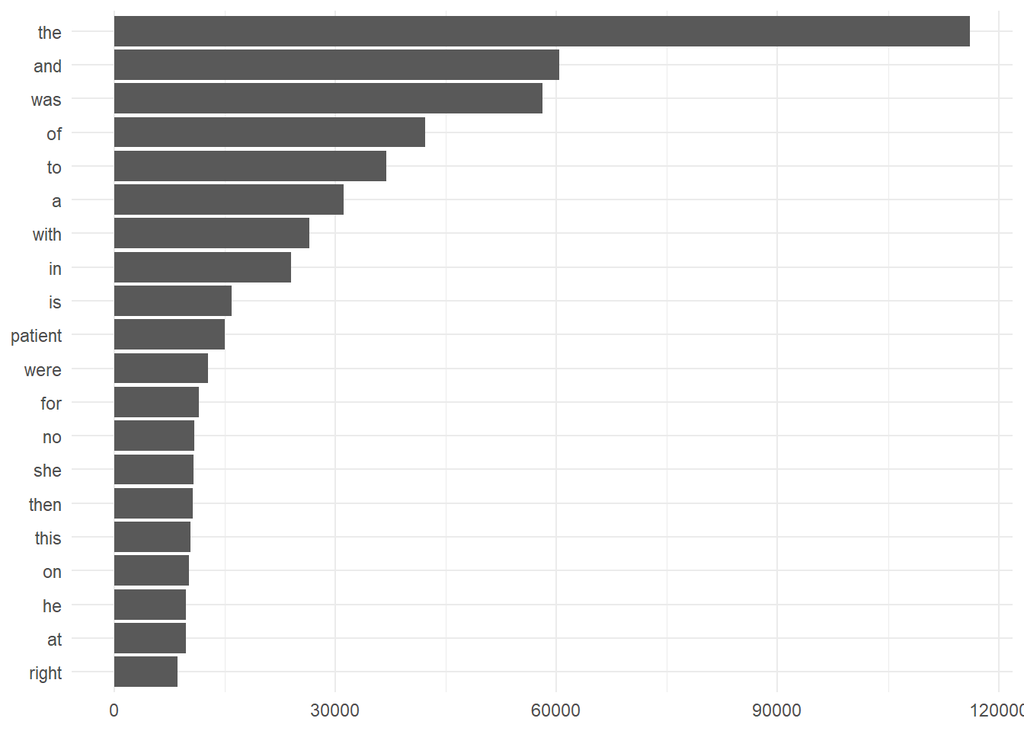

```r
tokens <- mt_samples |> select(transcription) |>
  unnest_tokens(word, transcription) |> count(word, sort = TRUE)



tokens |> slice_max(n, n = 20) |>
  ggplot(aes(reorder(word,n), n)) +
  theme_minimal() +
  geom_bar(stat = "identity") +
  coord_flip() +
  labs(x = NULL, y = NULL)
```

**Response:**

It makes sense that words like “the” and “and” appear the most often, since they are used the most often in sentences. However, these are considered stop words, which don’t really contribute any meaning to the transcription. Therefore, this motivates us to remove them. Even so, there are still significant words like “patient” in the top 20 count, which have meaning towards the transcription.

## Question 3

- Redo visualization for the top 20 most frequent words after removing stop words
- Bonus points if you remove numbers as well

What do we see know that we have removed stop words? Does it give us a better idea of what the text is about?

```r
library(stopwords)
head(stopwords("english"))
```

```
## [1] "i"      "me"     "my"     "myself" "we"     "our"
```

```r
length(stopwords("english"))
```

```
## [1] 175
```

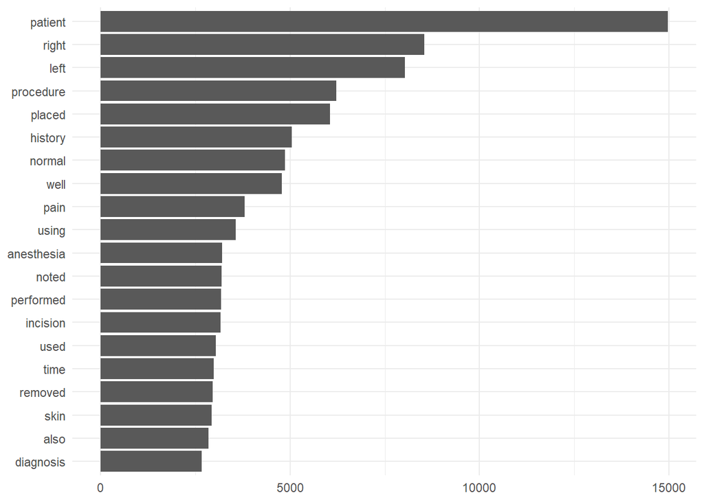

```r
#no stop words
tokens_no_stopwords <- tokens |>
  filter(!word %in% stopwords("english"), !grepl('^[0-9]',word, ignore.case = TRUE))

#barplot
tokens_no_stopwords |>
  slice_max(n, n = 20) |>
  ggplot(aes(reorder(word,n), n)) +
  theme_minimal() +
  geom_bar(stat = "identity") +
  coord_flip() +
  labs(x = NULL, y = NULL)
```

Another method for visualizing word counts is using a word cloud via `wordcloud::wordcloud()`. Create a world cloud for the top 50 most frequent words after removing stop words (and numbers).

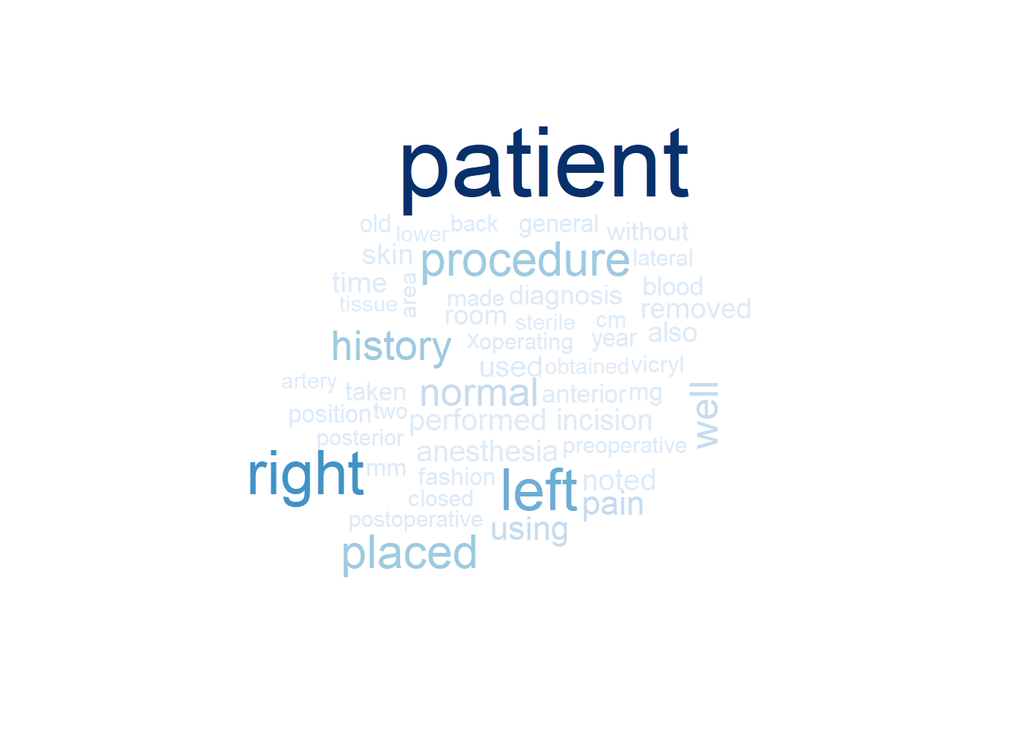

```r
library(wordcloud)
#top 50 wordcloud
tokens50 = tokens_no_stopwords |>
  slice_max(n, n= 50)
wordcloud(tokens50$word, tokens50$n, colors = brewer.pal(9,"Blues"))
```

# Question 4

Repeat question 3, but this time tokenize into bi-grams. How does the result change if you look at tri-grams? (You don’t need to create the word clouds.)

```r
sw_start <- paste0("^", paste(stopwords("english"), collapse = " |^"), " ")

sw_end <- paste0(" ", paste(stopwords("english"), collapse = "$| "), "$")


tokens_bigram <- mt_samples |> select(transcription) |>
  unnest_tokens(ngram, transcription, token = "ngrams", n= 2) |>
  filter(
    #remove those with stop words
    !grepl(sw_start,ngram, ignore.case = TRUE),
        !grepl(sw_end ,ngram, ignore.case = TRUE),
    #remove numbers
  !grepl('^[0-9]',ngram, ignore.case = TRUE),
    !grepl('[0-9]$',ngram, ignore.case = TRUE),

  ) |>
  count(ngram)
```

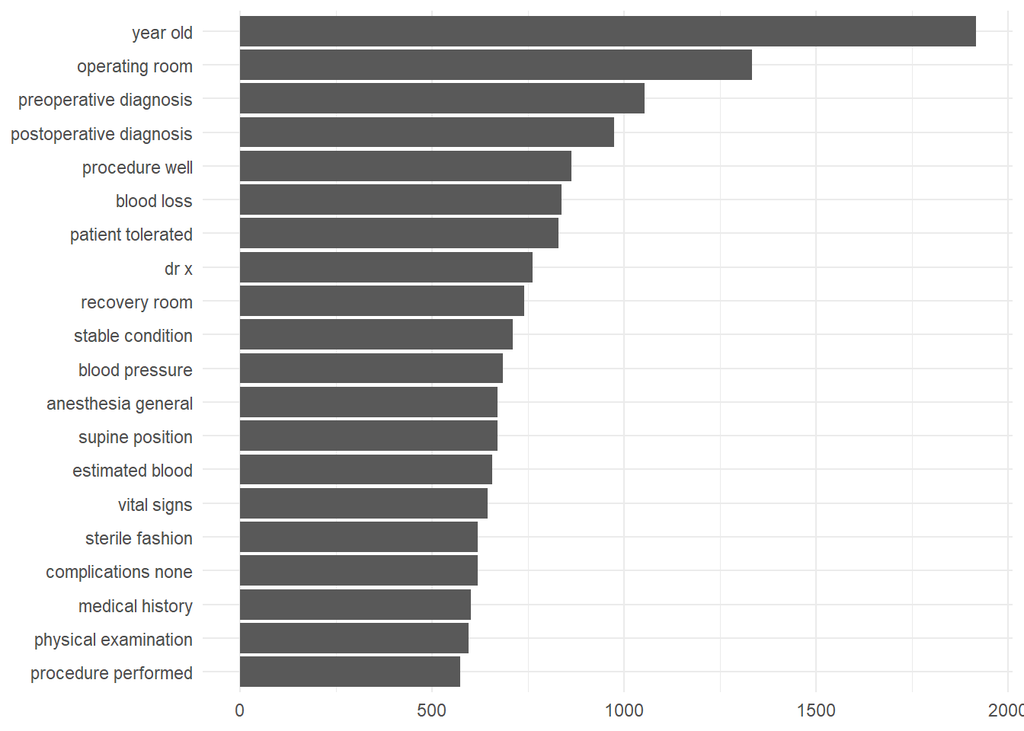

```r
# bar plots
tokens_bigram |>
  slice_max(n, n = 20) |>
  ggplot(aes(reorder(ngram,n), n)) +
  theme_minimal() +
  geom_bar(stat = "identity") +
  coord_flip() +
  labs(x = NULL, y = NULL)
```

# Question 5

Using the results you got from question 4. Pick a word and count the words that appears after or before it. Also, try finding pairs of words after and before the word.

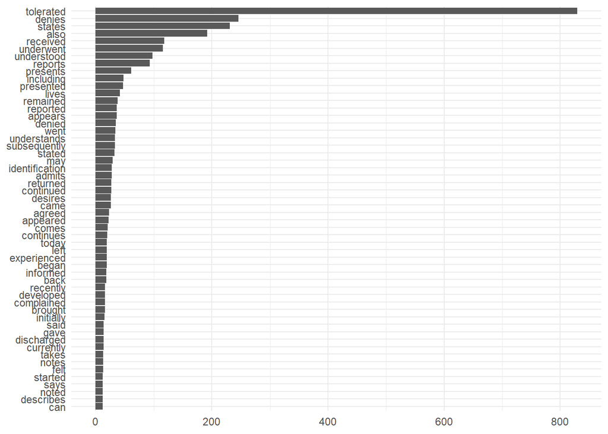

```r
library(stringr)

tokens_bigram |>
  filter(str_detect(ngram, regex("\\spatients$|^patient\\s"))) |>
  mutate(word = str_remove(ngram, "patient"),
         word = str_remove_all(word, " ")) |>
  group_by(word) |>
  summarise(n = sum(n)) |>
  slice_max(n, n = 50) |>
  ggplot(aes(reorder(word, n), n)) +
  theme_minimal() +
  geom_bar(stat = "identity") +
  coord_flip() +
  labs(x = NULL, y = NULL)
```

# Question 6

Which words are most used in each of the specialties. you can use `group_by()` and `top_n()` from `dplyr` to have the calculations be done within each specialty. Remember to remove stop words. How about the most 5 used words?

```r
tokens <- mt_samples |> select(transcription, medical_specialty) |>
  unnest_tokens(word, transcription)

tokens_no_stopwords <- tokens |>
  filter(!word %in% stopwords("english"),
         !grepl("\\d+", word, ignore.case = TRUE))


# most used words in each of the speciality
tokens_no_stopwords  %>% group_by(medical_specialty)%>%
 count(word, sort = TRUE)%>% top_n(n = 5)
```

```
## # A tibble: 171 × 3
## # Groups:   medical_specialty [30]
##    medical_specialty word          n
##    <chr>             <chr>     <int>
##  1 Surgery           patient    4855
##  2 Surgery           left       3263
##  3 Surgery           right      3261
##  4 Surgery           procedure  3243
##  5 Surgery           placed     3025
##  6 Orthopedic        patient    1711
##  7 General Medicine  patient    1356
##  8 Orthopedic        right      1172
##  9 General Medicine  history    1027
## 10 Orthopedic        left        998
## # … with 161 more rows
```

# Question 7 - extra

Find your own insight in the data:

Ideas:

- Use TF-IDF to see if certain words are used more in some specialties then others. Compare the list of words compared to the list from Question 6.

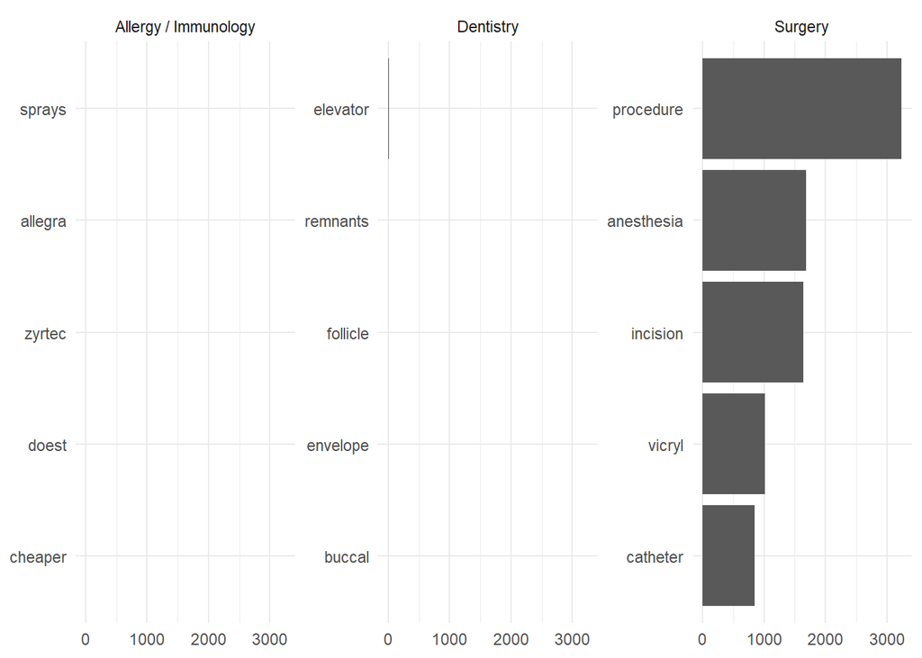

```r
tf_idf_by_speciality <- mt_samples |>
  unnest_tokens(word, transcription) |>
  filter(!word %in% stopwords("english")) |>
  count(word, medical_specialty) |>
  bind_tf_idf(word, medical_specialty, n) |>
  group_by(medical_specialty)

tf_idf_by_speciality %>%
 slice_max(tf_idf , n = 5) |>
  filter(medical_specialty %in% c("Surgery" , "Dentistry", "Allergy / Immunology")) |>
  ggplot(aes(reorder(word, n), n)) +
  theme_minimal() +
  geom_bar(stat = "identity") +
  coord_flip() +
  labs(x = NULL, y = NULL)+
    facet_wrap(~ medical_specialty, scales = "free_y")
```

```r
#other
a <- mt_samples |> filter(str_detect(transcription, " elevator ")) |>
  pull(transcription)
```

- Sentiment analysis to see if certain specialties are more optimistic than others. How would you define “optimistic”?

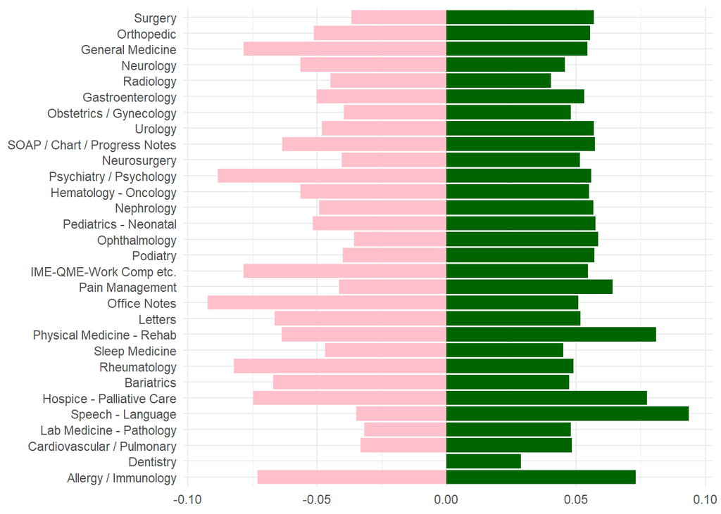

```r
sentiment_list <- get_sentiments("bing")

sentiments_in_med <- tf_idf_by_speciality |> left_join(sentiment_list, by = "word")


sentiments_in_med_by_sp <- sentiments_in_med |>
  group_by(medical_specialty) |>
  summarise(n_positive = sum(ifelse(sentiment == "positive",n, 0 ), na.rm = TRUE),
            n_negative = sum(ifelse(sentiment == "negative",n, 0), na.rm = TRUE),
n = sum(n))

sentiments_in_med_by_sp |>
  ggplot(aes(reorder(medical_specialty, n))) +
  theme_minimal() +
  geom_col(aes(y = - n_negative / n), fill =  "pink") +
    geom_col(aes(y = n_positive / n), fill =  "darkgreen" ) +
   coord_flip() +
  labs(x = NULL, y = NULL)
```

- Find which specialty writes the longest sentences.

```r
#tokenize in sentences
tokens <- mt_samples |> select(transcription, medical_specialty) |>
  unnest_tokens(sentence, transcription, token = "sentences")

#create summary table of sentence length for each specicalty
tokens %>% mutate(length = str_count(sentence, "\\w+"))  %>% group_by(medical_specialty) %>% summarise(average_length = mean(length), max_length = max(length), min_length = min(length), n = n())%>% arrange(desc(average_length))
```

```
## # A tibble: 30 × 5
##    medical_specialty         average_length max_length min_length     n
##    <chr>                              <dbl>      <int>      <int> <int>
##  1 Speech - Language                   24.1         75          1   159
##  2 Neurosurgery                        19.0        256          1  2971
##  3 Psychiatry / Psychology             18.9        208          1  2366
##  4 Dentistry                           18.6         89          9    25
##  5 Podiatry                            18.4        183          1  1263
##  6 Sleep Medicine                      18.3        125          2   338
##  7 Physical Medicine - Rehab           18.3         85          1   533
##  8 Lab Medicine - Pathology            18.1        105          1   111
##  9 IME-QME-Work Comp etc.              17.9        108          1  1006
## 10 Orthopedic                          17.6        256          1 11738
## # … with 20 more rows
```

**Response:**

Speech specialty has the longest sentences on average.

# Deliverables

1. Questions 1-7 answered, pdf or html output uploaded to Quercus